# Diary

Divya Purohith

November 16, 2018

I have chosen base R to learn..

**Data Visualization**

```r
library(MASS)
```

Two types of data visualization:

**Exploratory visualizations** help us understand the data. It keeps as much details as possible. **Explanatory visualizations** help us share our understanding with others. It highlights the key features you want to emphasize in the data.

R supports both types of visualization.

**There are 4 graphics systems in R** Base graphics: Easiest to learn and focus of this course Grid graphics: powerful set of modules for building other tools La!ice graphics: general purpose system based on grid graphics ggplot2: Grammar of graphics

```r
str(whiteside)
```

```
## 'data.frame':    56 obs. of  3 variables:
##  $ Insul: Factor w/ 2 levels "Before","After": 1 1 1 1 1 1 1 1 1 1 ...
##  $ Temp : num  -0.8 -0.7 0.4 2.5 2.9 3.2 3.6 3.9 4.2 4.3 ...
##  $ Gas  : num  7.2 6.9 6.4 6 5.8 5.8 5.6 4.7 5.8 5.2 ...
```

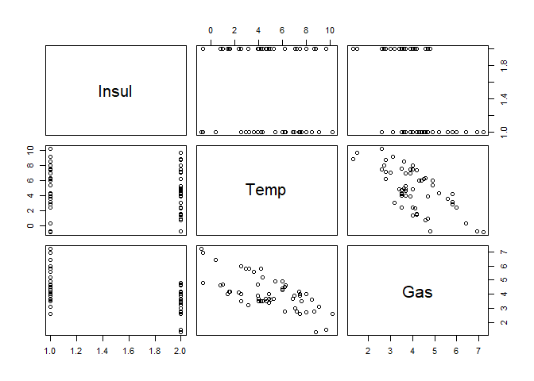

```r
plot(whiteside)
```

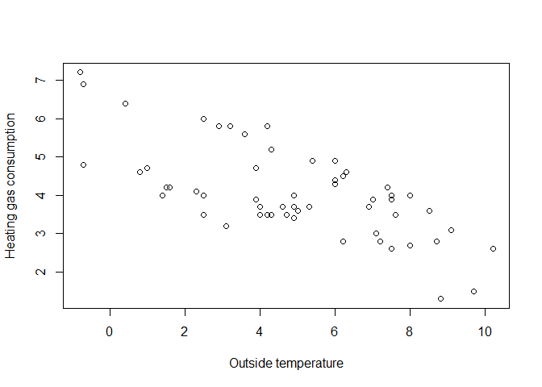

```r
plot(whiteside$Temp, whiteside$Gas, xlab = "Outside temperature", ylab = "Heating gas consumption")
```

Example of plot: plot(data$cars,data$minds). It will take data$cars automatically as X and the other one as y. We can also add title with title(“cars vs minds”).

For grid graphics we need to load the grid package.

**There are different plors in R** 1. Scatter plot 2. Sunflower plot 3. Boxplot (Used to know the range of numerical variables in the data. This is to see the distrubution, I am gonna use this for my drosophila egg laying data). 4. Mosaic plot(Relationship between the variables) 5. Pie charts are the poor choice to use.

**Graphics** Graphics can be low level or high level we can even add colour and shapes to the points,lines and texts in our graphs. Shapes of the points can be specified either by the number or single alphabetic letter.

**CHARACTERIZING A SINGLE VARIABLE** histogram is the best way to look how the numeric variables are disturbuted over their range hist() is the function used. truehist() is the alternate form of hist.

qqPlot()

Visualization relations between two variables

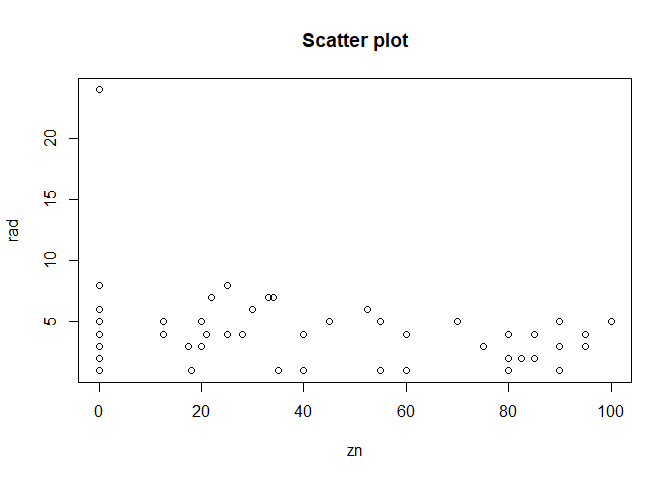

```r
library(MASS)
plot(rad ~zn, data = Boston) #Gives scatterplot.
title("Scatter plot")
```

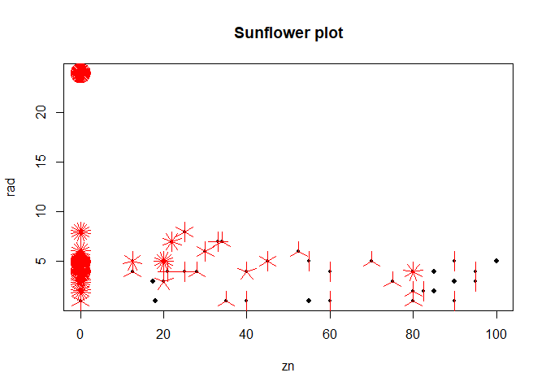

```r
library(MASS)
sunflowerplot(rad ~zn, data = Boston)
title("Sunflower plot")
```

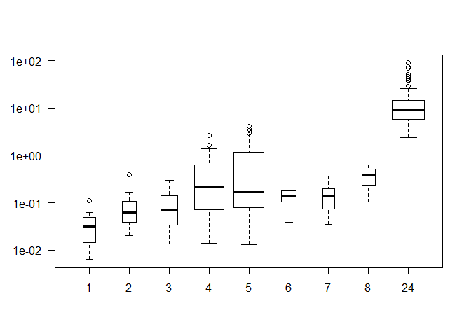

```r
boxplot(crim ~ rad, #showing the distribution of numerical crim values over the different distinct rad values
  data = Boston,
  varwidth = T,
  log = "y", #logtransformed values for y
  las = 1) #horizontal labels for both x and y
```

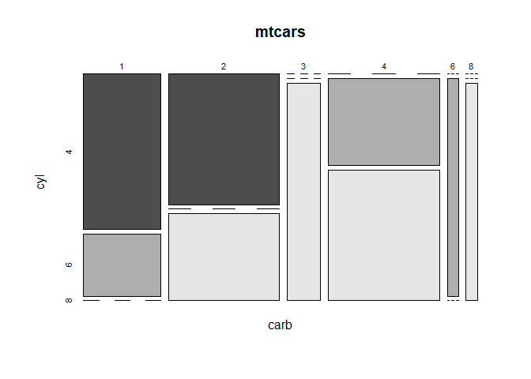

```r
mosaicplot(carb ~ cyl,
  data = mtcars,
  color = T) #color true will keep the color
```

```r
  #mosaic with inbuilt mtcars R example
```

# For bagplot we need to load aplpack

```r
library(aplpack)
```

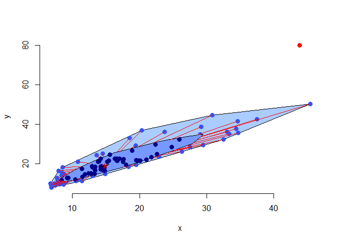

```r
bagplot(Cars93$Min.Price, Cars93$Max.Price, cex= 1.20) #cex to make the point size bigger
```

# showing more complex relationships

corplot() library(corplot) sapply(dataset, is.numeric) #corelation matrices for multiple variables

```r
library(corrplot)
col_numeric <- sapply(Boston, is.numeric)
numericalVars <- Boston[, col_numeric]
str(numericalVars)
```

```
## 'data.frame':    506 obs. of  14 variables:
##  $ crim   : num  0.00632 0.02731 0.02729 0.03237 0.06905 ...
##  $ zn     : num  18 0 0 0 0 0 12.5 12.5 12.5 12.5 ...
##  $ indus  : num  2.31 7.07 7.07 2.18 2.18 2.18 7.87 7.87 7.87 7.87 ...
##  $ chas   : int  0 0 0 0 0 0 0 0 0 0 ...
##  $ nox    : num  0.538 0.469 0.469 0.458 0.458 0.458 0.524 0.524 0.524 0.524 ...
##  $ rm     : num  6.58 6.42 7.18 7 7.15 ...
##  $ age    : num  65.2 78.9 61.1 45.8 54.2 58.7 66.6 96.1 100 85.9 ...
##  $ dis    : num  4.09 4.97 4.97 6.06 6.06 ...
##  $ rad    : int  1 2 2 3 3 3 5 5 5 5 ...
##  $ tax    : num  296 242 242 222 222 222 311 311 311 311 ...
##  $ ptratio: num  15.3 17.8 17.8 18.7 18.7 18.7 15.2 15.2 15.2 15.2 ...
##  $ black  : num  397 397 393 395 397 ...
##  $ lstat  : num  4.98 9.14 4.03 2.94 5.33 ...
##  $ medv   : num  24 21.6 34.7 33.4 36.2 28.7 22.9 27.1 16.5 18.9 ...
```

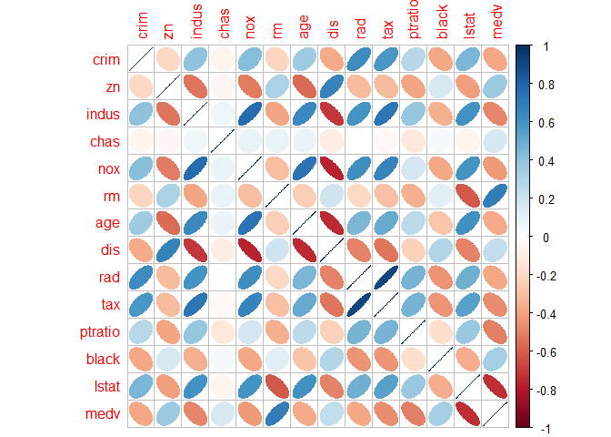

```r
corrMat <- cor(numericalVars)
corrplot(corrMat, method = "ellipse")
```

rpart() library(rpart) #gives us tree models

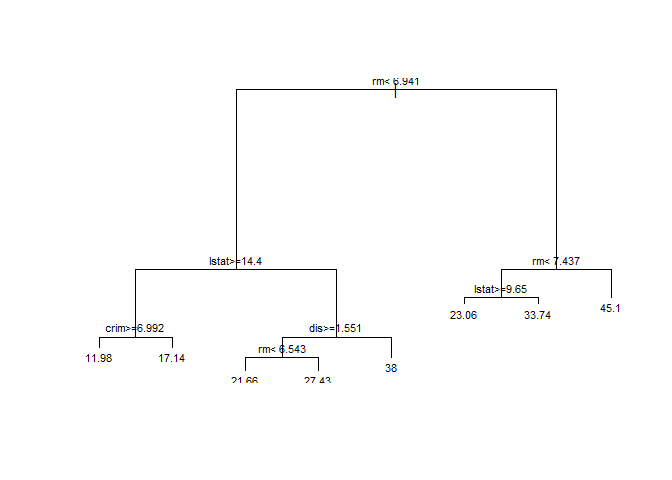

```r
library(rpart)
library(MASS)
tree_model <- rpart(medv ~ ., data = Boston)
plot(tree_model)
text(tree_model, cex = .7) #label easier to read
```

pch pch = 0,square pch = 1,circle pch = 2,triangle point up pch = 3,plus pch = 4,cross pch = 5,diamond pch = 6,triangle point down pch = 7,square cross pch = 8,star pch = 9,diamond plus pch = 10,circle plus pch = 11,triangles up and down pch = 12,square plus pch = 13,circle cross pch = 14,square and triangle down pch = 15, filled square pch = 16, filled circle pch = 17, filled triangle point-up pch = 18, filled diamond pch = 19, solid circle pch = 20,bullet (smaller circle) pch = 21, filled circle blue pch = 22, filled square blue pch = 23, filled diamond blue pch = 24, filled triangle point-up blue pch = 25, filled triangle point down blue

*linear regression model*

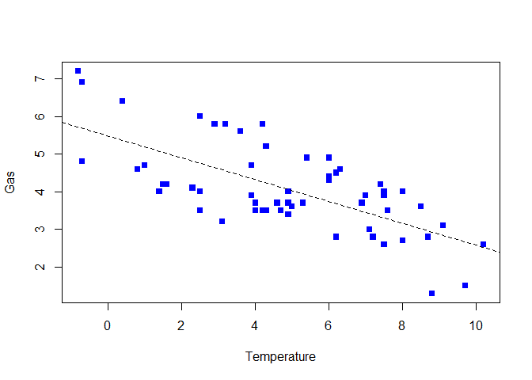

```r
linear_model <- lm(Gas ~ Temp, data = whiteside)
plot(whiteside$Temp, whiteside$Gas, xlab ="Temperature", ylab="Gas", pch=15,col="blue")
abline(linear_model, lty = 2)
```

#The font “face” (1=plain, 2=bold, 3=italic, 4=bold-italic) #srt can be positive or negative numbers. It rotates the labels par sets the parameters to the graphs

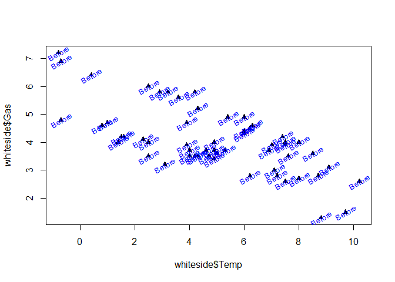

```r
plot(whiteside$Temp, whiteside$Gas, pch=17)
indecB <- which(whiteside$Insul == "Before")
text(x = whiteside$Temp, y = whiteside$Gas,
     labels = "Before", col = "blue", srt = 30, cex = .8) #srt here is positive. cex .8 will reduce 80% text size from default.
```

```r
#include text in the graph.
```

# Adding legend to the plot

adj moves the text to right or left.

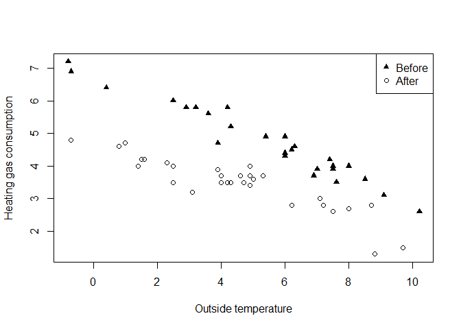

```r
plot(whiteside$Temp, whiteside$Gas,
     type = "n",
     xlab = "Outside temperature",
     ylab = "Heating gas consumption")
indexB <- which(whiteside$Insul == "Before")
indexA <- which(whiteside$Insul == "After")
points(whiteside$Temp[indexB], whiteside$Gas[indexB], pch = 17)
points(whiteside$Temp[indexA],whiteside$Gas[indexA], pch = 1)
legend("topright", pch = c(17,1),
       legend = c("Before", "After")) #legend is used to label the legend
```

# axis() adds axis to the plot. axis=1 is below, axis=2 is left, axis=3 is top, axis=4 is right.

if axis is fales, it creates no axis to the plot

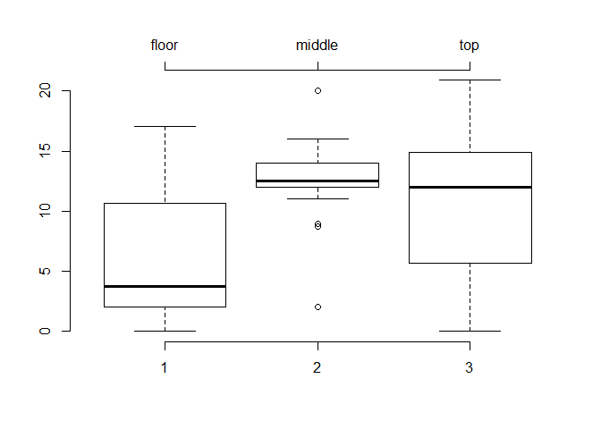

```r
boxplot(sugars ~ shelf, data = UScereal, axes = F)
axis(side = 2)
axis(side = 1, at = c(1,2,3)) #at add thes axis at specific numerics
axis(side = 3, at = c(1,2,3),
     labels = c("floor","middle","top")) #labels the given names at 1,2,3
```

supsmu() smooth values to the trendline, takes x and y values and incorporates to the graph.

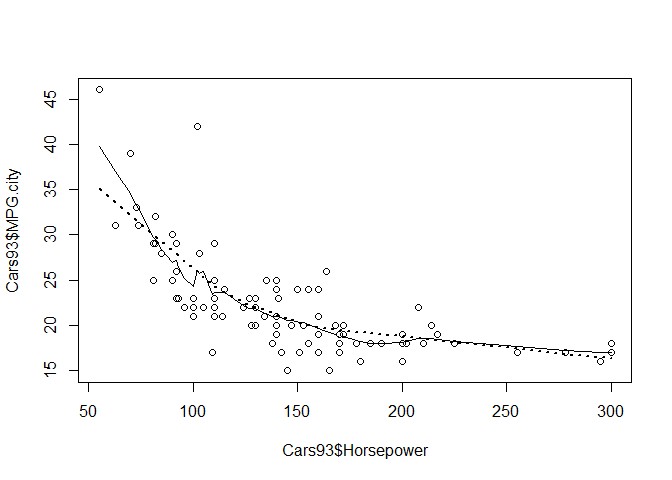

```r
plot(Cars93$Horsepower, Cars93$MPG.city)
trend1 <- supsmu(Cars93$Horsepower, Cars93$MPG.city)
lines(trend1)
trend2 <- supsmu(Cars93$Horsepower, Cars93$MPG.city, bass = 10)
lines(trend2, lty = 3, lwd = 2) #lwd is line-width #lty 3 is dotted line
```

*Managing visual complexity* matplot() , generates plot with various scatter plots on the same axes. matrix on y axis.

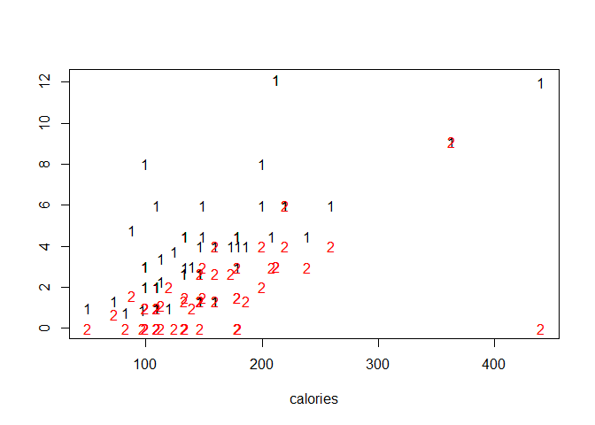

```r
matplot(
  UScereal$calories,
  UScereal[,c('protein', 'fat')],
  xlab = "calories",
  ylab = "")
```

wordcloud() wordclouds, displays that present words in varying sizes depending on their frequency. That is, more frequent words appear larger in the display, while rarer words appear in a smaller font. wordcloud(words = names(*), freq = as.numeric(*), scale =c(max,min)

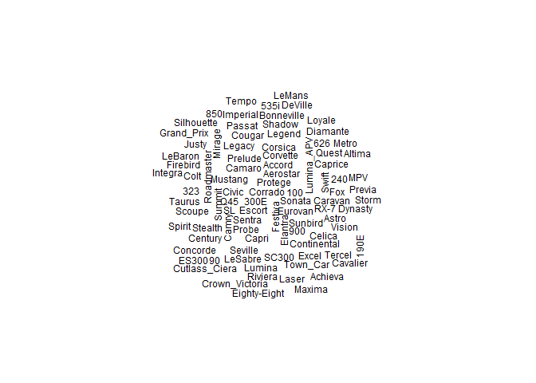

```r
library(wordcloud)
model_table <- table(Cars93$Model)
wordcloud(words = names(model_table),
          freq = as.numeric(model_table),
          scale = c(0.75,0.25), #tells how the wordcloud appears
          min.freq = 1)
```

*multple plot arrays* par() sets parameters to the graphs

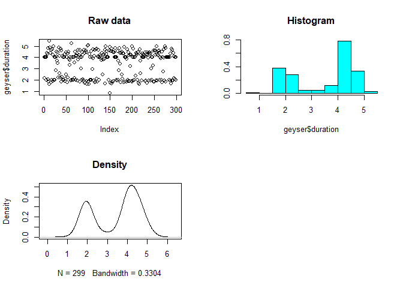

```r
par(mfrow = c(2,2))
plot(geyser$duration, main = "Raw data")
truehist(geyser$duration, main = "Histogram")
plot(density(geyser$duration), main = "Density")
```

layout()

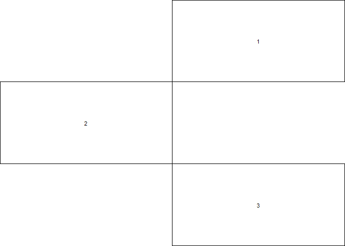

```r
layoutMatrix <- matrix(
  c( 0, 1, 2, 0,0, 3), byrow = T,nrow = 3) #nrow, tells there are 3
layout(layoutMatrix) #used the matrix constructed
layout.show(n = 3) #see layout of all 3 plots
```

barplot() function has the side effect of creating the plot we want, but it also returns a numerical vector with the center positions of each bar in the plot.

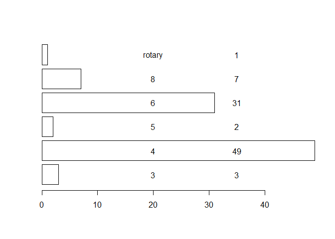

```r
tbl <- table(Cars93$Cylinders)
mids <- barplot(tbl, horiz = T,
                col = "transparent",
                names.arg = "")
text(20, mids, names(tbl)) #at the horizontal position 20
text(35, mids, as.numeric(tbl))
```

symbols() function to display relations between more than two variables The symbols() function allows us to extend scatterplots to show the influence of other variables.

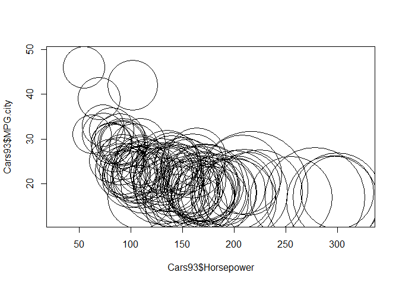

```r
symbols(Cars93$Horsepower, Cars93$MPG.city,
        circles = sqrt(Cars93$Price))
```

```r
        symbols(Cars93$Horsepower, Cars93$MPG.city,
        circles = sqrt(Cars93$Price),
        inches = 0.1)
```

[figure not shown]

```r
# Call png() with the name of the file we want to create
png('bubbleplot.png')
# Save our file and return to our interactive session
dev.off()
```

# Using colour to enhance bubble plot

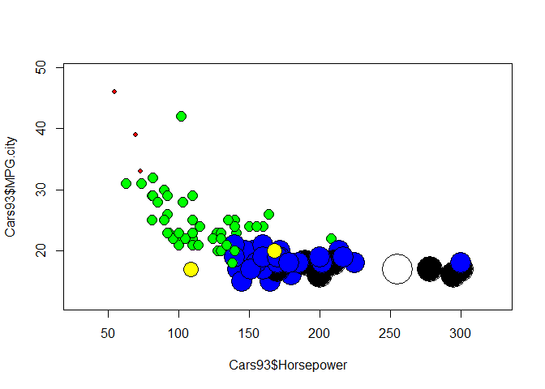

```r
IScolors <- c("red", "green", "yellow", "blue",
              "black", "white", "pink", "cyan",
              "gray", "orange", "brown", "purple")
cylinderLevel <- as.numeric(Cars93$Cylinders)
symbols(
  Cars93$Horsepower, Cars93$MPG.city,
  circles = as.numeric(Cars93$Cylinders),
  inches = 0.2, #size of bubbles
  bg = IScolors[cylinderLevel]) #bg is color of each bubble
```

Thetableplot() function constructs a set of side-by-side horizontal barplots, one for each variable

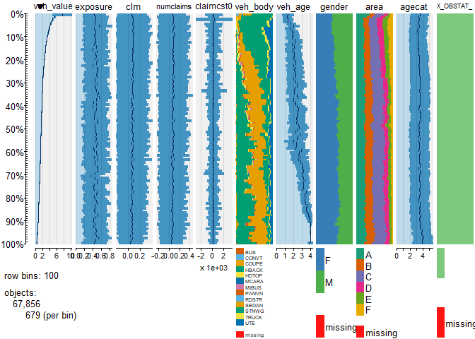

```r
library(insuranceData)
data(dataCar)
suppressPackageStartupMessages(library(tabplot))
tableplot(dataCar)
```

lattice xyplot() lattice is a general-purpose graphics package that provides alternative implementations of many of the plotting functions available in base graphics. Specific examples include scatterplots with the xyplot() function, bar charts with the barchart() function, and boxplots with the bwplot() function.

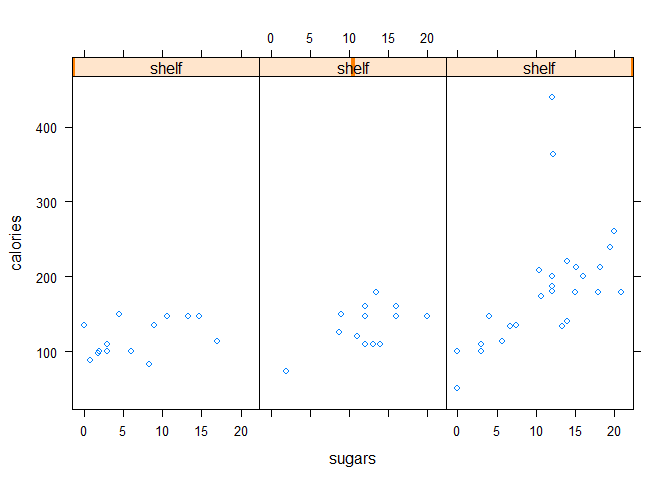

```r
library(lattice)
calories_vs_sugars_by_shelf <- calories ~ sugars | shelf
xyplot(calories_vs_sugars_by_shelf, data = UScereal)
```

ggplot2()

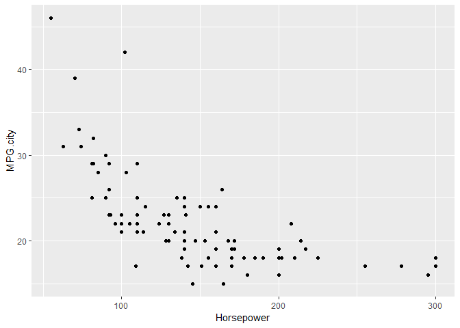

```r
# Load the ggplot2 package
library(ggplot2)

# Create the basic plot (not displayed): basePlot
basePlot <- ggplot(Cars93, aes(x = Horsepower, y = MPG.city))

# Display the basic scatterplot
basePlot +
  geom_point()
```

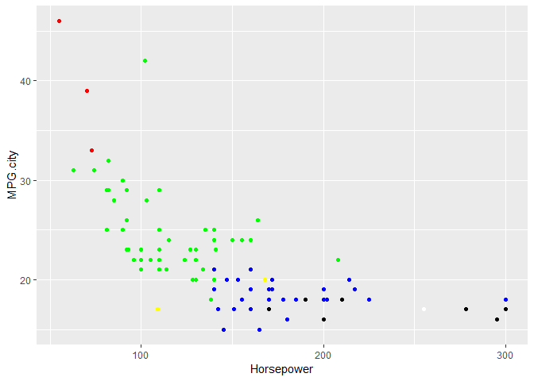

```r
# Color the points by Cylinders value
# Color the points by Cylinders value
basePlot +
  geom_point(colour = IScolors[Cars93$Cylinders])
```

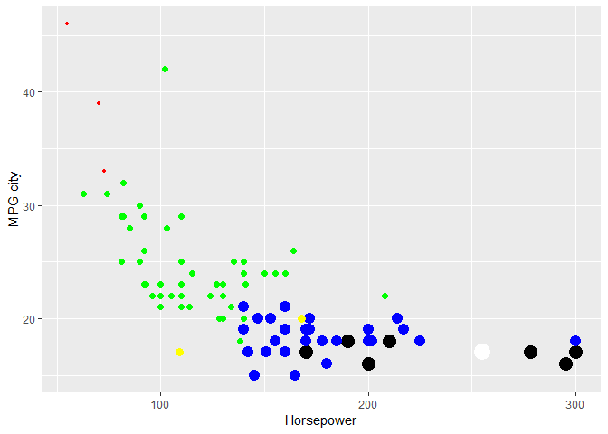

```r
# Make the point sizes also vary with Cylinders value
basePlot +
  geom_point(colour = IScolors[Cars93$Cylinders],
             size = as.numeric(Cars93$Cylinders))
```

I want to try what I have learnt on my own data. Introduction to my data.

There are three populations (described more completely in the “material and methods section”)  
1) C: “uncontrolled mating” (control)  
2) (O)M: “older male mated with younger female”  
3) (O)F: “older female mated with younger male”

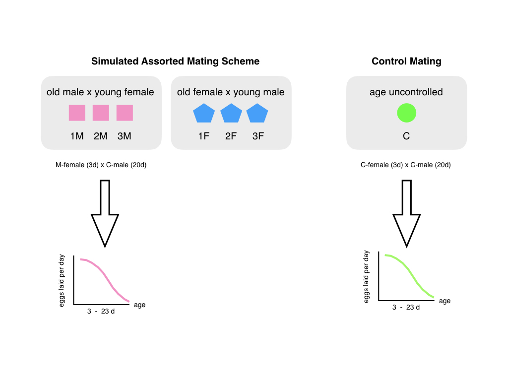

Pair “(3-23 d) fertility” was measured by mating a 20 day old Control virgin male with a 3 day old (O)M virgin female and recording eggs per day from 3 - 23 d.

```r
egg_data <- read.csv("CE_egg_transposed.csv",header=TRUE)
str(egg_data) # for structure of egg_data
```

```
## 'data.frame':    40 obs. of  51 variables:
##  $ Days_of_egg_laying: int  NA 1 NA 2 NA 3 NA 4 NA 5 ...
##  $ X1M_1             : int  NA 52 NA 54 NA 41 NA 17 NA 21 ...
##  $ X1M_2             : int  NA 53 NA 41 NA 39 NA 43 NA 19 ...
##  $ X1M_3             : int  NA 49 NA 43 NA 29 NA 17 NA 18 ...
##  $ X1M_4             : int  NA 47 NA 39 NA 43 NA 28 NA 23 ...
##  $ X1M_5             : int  NA 33 NA 36 NA 46 NA 38 NA 31 ...
##  $ X1M_6             : int  NA 48 NA 51 NA 42 NA 36 NA 21 ...
##  $ X1M_7             : int  NA 42 NA 38 NA 31 NA 37 NA 14 ...
##  $ X1M_8             : int  NA 36 NA 39 NA 27 NA 30 NA 22 ...
##  $ X1M_9             : int  NA 36 NA 43 NA 29 NA 40 NA 26 ...
##  $ X1M_10            : int  NA 43 NA 39 NA 47 NA NA NA NA ...
##  $ X2M_1             : int  NA 42 NA 40 NA 46 NA 37 NA 22 ...
##  $ X2M_2             : int  NA 37 NA 29 NA 35 NA 33 NA 17 ...
##  $ X2M_3             : int  NA 43 NA 36 NA 39 NA 36 NA 14 ...
```

[output cut: 37 more lines]

```r
colnames(egg_data) # column names
```

```
##  [1] "Days_of_egg_laying" "X1M_1"              "X1M_2"
##  [4] "X1M_3"              "X1M_4"              "X1M_5"
##  [7] "X1M_6"              "X1M_7"              "X1M_8"
## [10] "X1M_9"              "X1M_10"             "X2M_1"
## [13] "X2M_2"              "X2M_3"              "X2M_4"
## [16] "X2M_5"              "X2M_6"              "X2M_7"
## [19] "X2M_8"              "X2M_9"              "X2M_10"
## [22] "X3M_1"              "X3M_2"              "X3M_3"
## [25] "X3M_4"              "X3M_5"              "X3M_6"
## [28] "X3M_7"              "X3M_8"              "X3M_9"
## [31] "X3M_10"             "C_1"                "C_2"
## [34] "C_3"                "C_4"                "C_5"
## [37] "C_6"                "C_7"                "C_8"
## [40] "C_9"                "C_10"               "C_11"
## [43] "C_12"               "C_13"               "C_14"
## [46] "C_15"               "C_16"               "C_17"
## [49] "C_18"               "C_19"               "C_20"
```

```r
print(head(egg_data,n=10L)) # first 6 examples (rows) (by default)
```

```
##    Days_of_egg_laying X1M_1 X1M_2 X1M_3 X1M_4 X1M_5 X1M_6 X1M_7 X1M_8
## 1                  NA    NA    NA    NA    NA    NA    NA    NA    NA
## 2                   1    52    53    49    47    33    48    42    36
## 3                  NA    NA    NA    NA    NA    NA    NA    NA    NA
## 4                   2    54    41    43    39    36    51    38    39
## 5                  NA    NA    NA    NA    NA    NA    NA    NA    NA
## 6                   3    41    39    29    43    46    42    31    27
## 7                  NA    NA    NA    NA    NA    NA    NA    NA    NA
## 8                   4    17    43    17    28    38    36    37    30
## 9                  NA    NA    NA    NA    NA    NA    NA    NA    NA
## 10                  5    21    19    18    23    31    21    14    22
##    X1M_9 X1M_10 X2M_1 X2M_2 X2M_3 X2M_4 X2M_5 X2M_6 X2M_7 X2M_8 X2M_9
## 1     NA     NA    NA    NA    NA    NA    NA    NA    NA    NA    NA
## 2     36     43    42    37    43    39    39    38    48    39    52
## 3     NA     NA    NA    NA    NA    NA    NA    NA    NA    NA    NA
```

[output cut: 40 more lines]

```r
keep <- seq(from=2, to=40, by=2)
egg_data <- egg_data[keep,]
```

```r
print(head(egg_data,n=10L)) # first 6 examples (rows) (by default)
```

```
##    Days_of_egg_laying X1M_1 X1M_2 X1M_3 X1M_4 X1M_5 X1M_6 X1M_7 X1M_8
## 2                   1    52    53    49    47    33    48    42    36
## 4                   2    54    41    43    39    36    51    38    39
## 6                   3    41    39    29    43    46    42    31    27
## 8                   4    17    43    17    28    38    36    37    30
## 10                  5    21    19    18    23    31    21    14    22
## 12                  6    19    13    18    16    23    16    18    19
## 14                  7    15    11    13    14    23    16    11    14
## 16                  8    15    13    14    14    19    13    15    14
## 18                  9    17    14    15    11    17    14    16    13
## 20                 10    14    16    15    16    16    16    11     9
##    X1M_9 X1M_10 X2M_1 X2M_2 X2M_3 X2M_4 X2M_5 X2M_6 X2M_7 X2M_8 X2M_9
## 2     36     43    42    37    43    39    39    38    48    39    52
## 4     43     39    40    29    36    37    37    34    43    40    43
## 6     29     47    46    35    39    36    37    26    29    39    48
```

[output cut: 40 more lines]

# I actually tried learning about matplot, and what I can do to neaten up the grap is add type=‘l’. We can customize our mat plot graphs. type=l will give us the line graph instead of alphabets.

# One more thing I have learnt is labelling x and y axis. xlab and ylab is what we use to label the x and y axis is matplot.

# We can also, add title to the graph, main does that

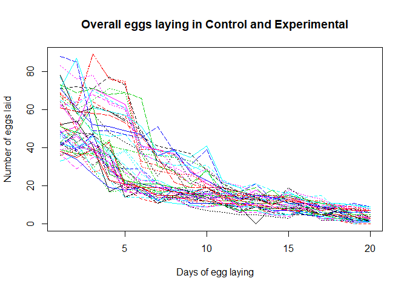

```r
# plot(egg_data$Days_of_egg_laying,egg_data$X1M_1)
# plot(egg_data$Days_of_egg_laying,egg_data$X1M_2)
y <- egg_data[2:51]
#print(y)
matplot(egg_data$Days_of_egg_laying,y, type='l', xlab = 'Days of egg laying', ylab = 'Number of eggs laid', main = 'Overall eggs laying in Control and Experimental')
```

```r
# matplot used because y is a matrix
```